# Virginia Math Bulletin

[figure not shown]

## View from the Chair

**John Imbrie, Professor of Mathematics/Chair**

I write at the conclusion of an extraordinary year for our department. As 2020 began, we were gearing up to host the AMS sectional, which was to start on March 12. Early indications were that large gatherings were a major contributor to the spread of the pandemic, so we hastily cancelled the event, which was to bring 700 participants to Charlottesville. Soon, the university cancelled classes and students were abruptly sent home. Faculty members and graduate students were tasked with quickly finding a way to hold classes online. The learning curve was steep, but we came together to reinvent our modes of teaching. Now we reach the conclusion of a semester with the majority of instruction still being delivered remotely.

[figure not shown]

The transition was, and continues to be, challenging, as many of us have put forth extraordinary time and effort while facing increasing demands caring for children and family members. Still, we have managed to thrive in ways that seemed out of reach in the dark days of March. Read ahead for an article by Leo Petrov on the ways we have managed to adapt to the new normal for teaching, research, and for our final exercises.

This year we are welcoming two new faculty members, Peter Humphries and Christian Reidys. Peter will start in the spring as his arrival in Charlottesville was delayed by the closure of the US embassy in Australia. Christian is one of the key figures in the new Biocomplexity Institute at UVa. Below, you will find profiles of them along with six new postdocs. The expanded postdoc roster includes two that are part of our multiyear program for transforming calculus instruction, and two that are supported by the Research Training Grant (RTG) – see last year’s Bulletin for a profile of the RTG grant.

This past summer we initiated a major new program for research experiences for undergraduates (REUs), combining Ken Ono’s long-running program in number theory with a new program in geometry and topology, supported by the RTG grant. Despite the challenges of working remotely, the program was very successful – see the article below by Ken Ono and Tom Mark. Other highlights of this Virginia Math Bulletin include an article on our new bridge program, by David Sherman (our new Director of Diversity, Equity, and Inclusion). Our Bridge to the Doctorate currently supports three post-baccalaureate students as they prepare for entry into a Ph.D. program.

Sadly, it was impossible to conduct the Gordon Keller math majors dinner. We had planned to host UVa graduate and McShane Prize winner Andrew Booker, who was in the news for work leading to the long-sought integer solutions to $x^3+y^3+z^3=33$ and $x^3+y^3+z^3=42$. We anxiously await the return of our normal activities, so that we can host Andrew and our majors once again.

In the meantime, with seminars and colloquia now delivered remotely via Zoom, we find that it is possible to participate remotely in lectures all over the world. I hope that our community of graduates and former members of the department will take this opportunity to reconnect with us by taking part in our online events. We’d love to hear from you as we move forward with another year of teaching, exploration, and discovery.

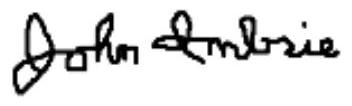

## Supporting Us

The Mathematics Department is grateful for the generous support of its alumni and friends. The Department welcomes gifts annually to address its most urgent needs, as well as to the endowment which provides funding in perpetuity. To learn about how you can make a difference by supporting the Mathematics Department, please contact Becky Balber at beckybalber@virginia.edu or (434) 243-4978. To make a gift online, please visit http://giving.as.virginia.edu/mathematics.

## New Faculty Profiles

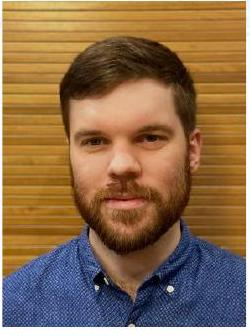

### Peter Humphries, Assistant Professor (2020–)

Mixing methods from analytic number theory, automorphic forms, and representation theory in his work, Peter Humphries is a pure mathematician working broadly in the area of number theory, which involves the study of prime numbers and their distribution. His research has applications towards quantum chaos, and he is particularly interested in problems involving equidistribution and $L$-functions.

Humphries has published 13 papers in research journals such as Geometric and Functional Analysis, Compositio Mathematica, Mathematische Annalen, and Communications in Mathematical Physics. As a master’s student, Humphries was awarded the J. G. Crawford prize by the Australian National University, a university-wide award in recognition of an outstanding research thesis.

Hailing from Melbourne, Australia, Humphries received his bachelor’s and master’s degrees from the Australian National University. He earned his Ph.D. in 2017 from Princeton University. Before joining UVA, he was a research associate at University College London, where he was funded by a grant from the European Research Council.

Humphries will be teaching Calculus III next spring.

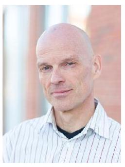

### Christian Reidys, Professor (2020–)

Christian Reidys has a joint appointment between the Mathematics Department and the Biocomplexity Institute at UVa. He is Director of the Mathematical Biocomplexity Division within the Biocomplexity Institute. His research is focused on discrete mathematics, computational biology, molecular evolution, RNA structure, DNA combinatorics, and topology of large data sets. This fall, he taught a graduate class in bio-mathematics. He has been advising postdocs Thomas Li, Ricky Chen, and Qijun He at the Biocomplexity Institute.

Reidys received his Ph.D. in 1995 from the University of Jena, Germany. He did postdoctoral work at the Los Alamos National Laboratory, and continued on staff member there until he became Professor at the Combinatorics Center at Nankai University, in 2006. He was Professor at the University of Southern Denmark from 2011-2015, after which he became Director and Professor at the Biocomplexity Institute at Virginia Tech. He is the author of two books, Combinatorial and Computational Biology of Pseudoknot RNA and An Introduction to Sequential Dynamical Systems.

### Filippo Mazzoli, Whyburn Research Associate (2020–)

Mazzoli’s research interests lie in the broad realm of geometry and topology. More specifically, he works in hyperbolic and anti-de Sitter geometry, Teichmüller theory and low-dimensional topology. Mazzoli’s main

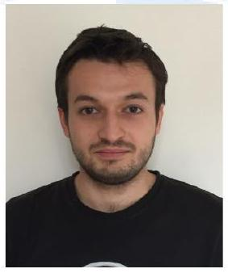

topic of research is the study of the deformation spaces of hyperbolic $3$-manifolds, and their geometric properties. He is particularly interested in the relations between the geometry of the Teichmüller space (deformation space of conformal structures or hyperbolic metrics on a surface) and the notions of dual volume, $W$-volume and renormalized volume of hyperbolic $3$-manifolds. He is also interested in the study of quantum invariants of finite volume hyperbolic $3$-manifolds, and their connections with hyperbolic geometry. In his work, he uses techniques from differential geometry, geometric topology, and symplectic geometry.

Mazzoli received both his B.S. in mathematics (2014) and his M.S. in mathematics (2016) from the University of Pisa, Italy. He earned a Ph.D. in Mathematics from the University of Luxembourg (2020). In his teaching, he tries to always share with his students his enthusiasm for mathematics. This year, Mazzoli is teaching Calculus III and Applied Linear Algebra.

### William Olsen, RTG Research Associate (2020–)

William Olsen works in geometric topology, with particular interest in smooth $4$-dimensional manifolds. His doctoral dissertation provided

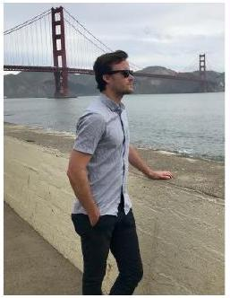

the first concrete relationship between the powerful invariants of smooth $4$-manifolds defined by Ozsváth and Szabó on the one hand, and the theory of trisections of $4$-manifolds on the other. Ozsváth-Szabó theory provides a means to study subtle properties of smooth $4$-manifolds, for example distinguishing between manifolds that are homeomorphic but not diffeomorphic, while the theory of trisections is a rapidly developing field that gives an essentially combinatorial method to describe and manipulate $4$-manifolds. By demonstrating a connection between these fields, Bill’s thesis is pointing the way to further developments in both areas.

Bill finished his Ph.D. in 2020 at the University of Georgia, where his dissertation advisor was David Gay; he spent the year 2019-20 as a visitor at the Max Planck Institute in Bonn, Germany. Bill joins UVa with support from the department’s RTG grant from the National Science Foundation, and besides teaching regular classes will assist in the department’s summer research programs for undergraduates.

### Thomas Polstra, Research Associate (2020–)

Thomas Polstra’s research interests lie in Commutative Algebra. More specifically, his research specialties include prime characteristic singularities, uniformity in

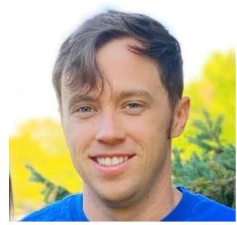

commutative algebra, the behavior of numerical measurements of singularities, and the theory of surface singularities. At UVA he is working with Craig Huneke. Prior to joining the mathematics department at the University of Virginia, Thomas was a National Science Foundation postdoc at the University of Utah after receiving his PhD at the University of Missouri. Thomas has served the mathematics community by organizing high school math circles, organizing conferences, designing a REU course, and mentoring undergraduate research projects. This year, Polstra is teaching Calculus II.

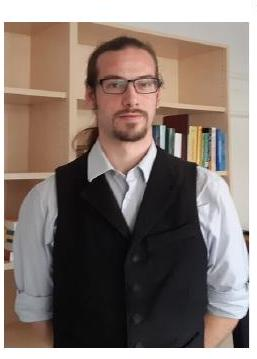

### Walker Stern, RTG Research Associate (2020–)

Walker Stern works in higher category theory, with applications to homotopy theory, algebra, and mathematical physics. His current research interests include $2$-Segal spaces, topological field theories, and $(\infty, 2)$ categories.

Walker received his BA and MA at Brandeis University and spent a year teaching at Wentworth Institute of Technology before moving to Germany for graduate school. He received his doctorate in mathematics from Universität Bonn under the direction of Toby Dyckerhoff. Before coming to UVA, he was a postdoc for one year at Universität Hamburg. This year, Stern is teaching Calculus III and Introduction to Geometry.

### Wei-Lun Tsai, Research Associate (2020–)

Wei-Lun Tsai hails from Taiwan, where he earned his undergraduate degree from National Taiwan University in 2010, and a Master’s degree in 2012. He earned his Ph.D. from Texas A&M University in 2020, where he was advised by Riad Masri.

Wei-Lun Tsai’s research interests are in

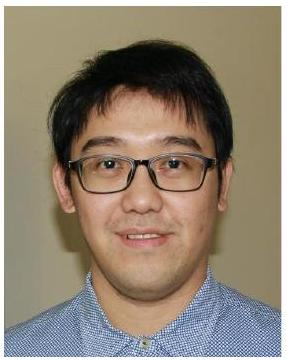

arithmetic geometry and algebraic and analytic number theory. His research specialties include the theory of class groups for number fields, rational elliptic curves, harmonic Maass forms, and $L$-functions. He will be working in the Algebra Group, and he will be  
mentored by Ken Ono. Tsai and Ono began their collaboration in May 2020, and they have already written a few joint papers on elliptic curves and modular forms. Furthermore, Tsai served as a research mentor in the 2020 UVA REU.

Before joining the UVA Department of Mathematics, Tsai mentored undergraduate students for two semesters through the Texas A&M University Directed Reading Program (DRP). Also, for three summers he served as a Teaching Assistant for the REU at Texas A&M University. He worked in the number theory research group, mentoring a total of seven students over the past three summers. He co-authored three papers with these students; one has been published in Mathematical Research Letters, one has been published in Journal of Number Theory, and one is submitted for publication. One of these students won a Goldwater Scholarship and the 2019 Joint Mathematics Meetings–Student Poster Session Award.

Tsai has taught various mathematics courses, from college level to graduate level, including Mathematical Concepts, Calculus (and pre-calculus), and Complex Analysis. He believes that teaching and mentoring are extremely important parts of the profession of mathematics. He is now passionate about both teaching and research, and he is excited to develop his skills in these areas at UVA. This year, Tsai is teaching Calculus III and Survey of Algebra.

### Gennady Uraltsev, Whyburn Research Associate (2020–)

Gennady received his Ph.D. in mathematics from Bonn University and prior to joining UVA he was a H.C. Wang postdoc at the Cornell Math Department. Gena’s research interests

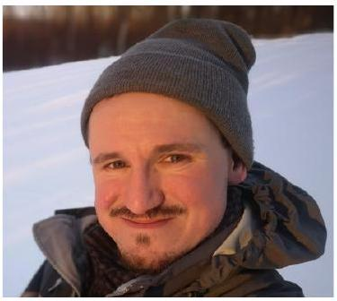

are in real-variable harmonic analysis and the theory of singular integral operators. His main area of work is in time-frequency analysis, an area initiated by Carleson with his celebrated result on the pointwise convergence of Fourier series for square integrable functions.

Gena’s PhD thesis (2016) was concerned with further developing Do-Thiele’s Lebesgue space theory over outer measures. After his thesis, Gena has written papers about vector valued and weighted bounds for classical operators in time frequency analysis, such as the variation-norm Carleson operator and the bilinear Hilbert transform. He is looking for other applications of the new methods to study important open problems in harmonic analysis, such as the question about uniform estimates for the bilinear Hilbert transform. This year, Uraltsev is teaching Calculus III and Basic Real Analysis.

## Faculty Awards and Honors

### Leonid Petrov Receives the 2020 Bernoulli Prize for a Joint Paper

The Bernoulli Prize for an Outstanding Survey Article is to recognize authors of an influential survey publication in probability. The 2020 prize is given

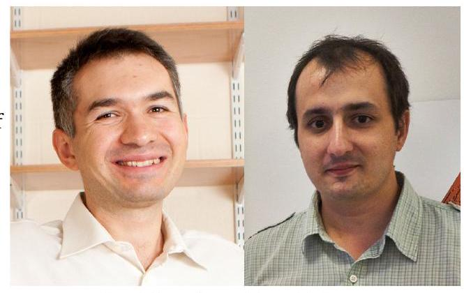

Alexei Borodin and Leonid Petrov

to Alexei Borodin (MIT) and Leonid Petrov (UVA) for the article *Integrable probability: From representation theory to Macdonald processes*. *Probability Surveys*, v.11:1-58, 2014.

### Popular Mechanics Honors Ken Ono and Andrew Booker for the Top Two Math Breakthroughs in 2019

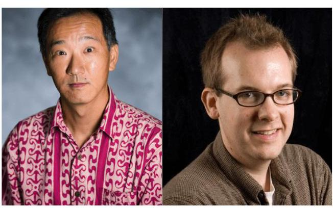

Ken Ono and Andrew Booker

In a recent Popular Mechanics article UVa faculty member Ken Ono was honored along with co-authors Michael Griffin, Larry Rolen, and Don Zagier for their work on a problem directly related to the Riemann Hypothesis. UVa graduate and McShane Prize winner Andrew Booker was cited along with Andrew Sutherland for work leading to the long-sought integer solutions to $x^{3}+y^{3}+z^{3}=33$ and $x^{3}+y^{3}+z^{3}=42$.

### Paul Bourdon and Sara Maloni Win 2020 All-University Teaching Awards

We are happy to announce that Sara Maloni and Paul Bourdon are receiving University of Virginia All-University Teaching Awards.

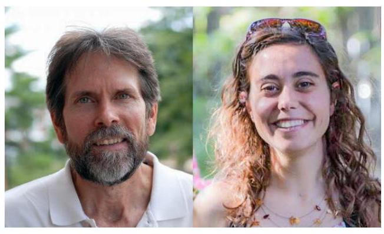

Paul Bourdon and Sara Maloni

They are among this year’s group of ten recipients.

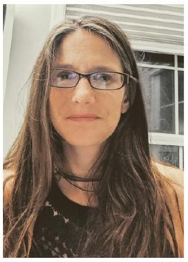

Jennifer Morse

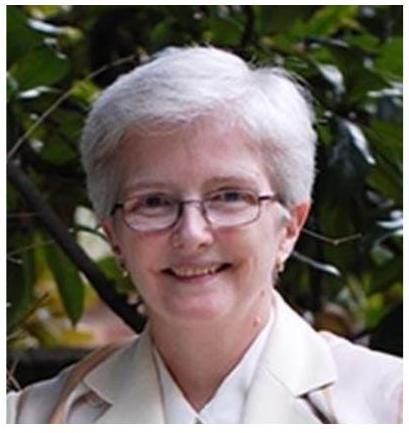

Karen Parshall

### Ken Ono Elected Chair of the Mathematics Section of AAAS

Ken Ono was elected Chair of the Mathematics Section of the American Association for the Advancement of Science.

### Jennifer Morse Elected to Fellows of the AMS

Congratulations to Professor Jennifer Morse for being elected to the 2021 Class of Fellows of the AMS, "for contributions to algebraic combinatorics and representation theory and service to the mathematical community".

### Ken Ono Named Among the Most Influential Mathematicians

Ken Ono, Thomas Jefferson Professor of Mathematics, has been named the 15th most influential mathematician by Academic Influence.

### Karen Parshall Elected Fellow of AAAS

Congratulations to Commonwealth Professor of Mathematics and History Karen Parshall who was elected as a Fellow of the American Association for the Advancement of Science, "for outstanding contributions to the history of mathematics, combined with extraordinary service to the mathematical and historical sciences."

### Ken Ono Awarded Honorary Professorship at IIT Guwahati

We are pleased to announce that Professor Ken Ono was awarded Honorary Professorship at Indian Institute of Technology, Guwahati.

## Faculty Research

### Wrapping Polynomial Computations in Combinatorics

*By Jennifer Morse*

Remember when you were taught to expand $(x+y)^{2}$, multiplying out term by term? It wasn’t particularly hard, but I doubt your teacher would

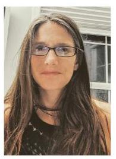

have gotten a shiny, red apple for asking you to expand out $(x+y)^{6}$ on a quiz. Were you thrown for a loop when discovering that the same expansion allows you to compute some nasty trig integrals and to prove the power rule in Calculus? Did you again turn to multiplying polynomials for intuition when finally learning the definition of an algebra (while being encouraged by your 12 year old sister who was sailing through her own algebra homework)?

Polynomial computation doesn’t go away, but would you believe that it can be beautifully wrapped in a game of counting? Finding the coefficient of $x^{2} y^{4}$ in $(x+y)^{6}$ turns into a matter of counting the ways to stack boxes against the wall of a $2 \times 4$ rectangle:

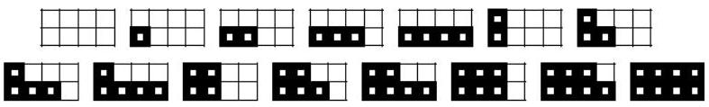

Such combinatorial solutions are not only elegant and fun, but they may simply be the only way to go. Computing with symmetric polynomials, multivariate polynomials with the property of being invariant under any permutation of the variables:  
$-17 X_{1} X_{2}-17 X_{1} X_{3}-17 X_{2} X_{3}$ but not $-17 X_{1} X_{2}-15 X_{1} X_{3}-17 X_{2} X_{3}$,  
is accomplished by a rule using a 100-year old combinatorial structure called Young tableaux (fill the above boxes with positive numbers so that they are increasing along rows and up columns). What’s more, the same rule for computing products of symmetric polynomials captures the structure of the cohomology of the variety of $r$-dimensional subspaces of $\mathbb{C}^{n}$ and the decomposition of Young modules into irreducible representations.

The challenge of finding a combinatorial structure to naturally facilitate computation is a central theme in algebraic combinatorics. My interest is to find creative ways to describe computational problems which have applications to enumerative geometry and representation theory. A broad class of problems connects with a distinguished family of multivariate polynomials called Macdonald polynomials. These are symmetric functions which arise in the wave equations of certain systems of quantum relativistic particles on a circle, and as the Frobenius images of bigraded Garsia-Haiman modules. Key information is stored in products of the distinguished families or in their coefficients when decomposed into more classical symmetric function bases. However, the computations are now extremely intricate and efficient rules are notoriously hard to come by.

This was my focus in the late 1990’s when Alain Lascoux, Luc Lapointe, and I uncovered the $k$-Schur functions (Duke Math. J. 2003). The $k$-Schur functions are a basis for the span of a subset of Macdonald polynomials determined by a positive integer $k$. These symmetric functions led Lapointe and me to a modernization of Young tableaux which is compatible with the Bruhat order on the type-$A$ affine Weyl group; a periodic coloring of the numbers comes into play:

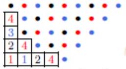

Our investigations led to the further discovery that parameterless $k$-Schur functions can be used to reflect the structure of quantum cohomology (products of $k$-Schur functions generate certain three-point Gromov-Witten invariants). Thomas Lam went on to prove a conjecture of Mark Shimozono that parameterless $k$-Schur functions represent Schubert classes for the homology of the affine Grassmannian of $\mathrm{SL}_{k+1}$ (J. Amer. Math. Soc. 2008).

These surprising connections strengthened my resolve to fully develop the combinatorics necessary for computing with $k$-Schur functions. Just recently, my work with Blasiak, Pun, and Summers (J. Amer. Math. Soc. 2019) settled problems posed with the inception of $k$-Schur functions 20 years prior. A key idea was that realizing $k$-Schur functions as a subclass of the larger family of Catalan functions offers powerful inductive techniques not available in a confined setting. Catalan functions are graded Euler characteristics of certain vector bundles on the flag variety, studied in greatest generality by Chen-Haiman (Berkeley Thesis 2010) and Panyushev (Selecta Math. 2010). The related combinatorial mechanism is given by Dyck paths, prescribing boxes stacked beneath a staircase:

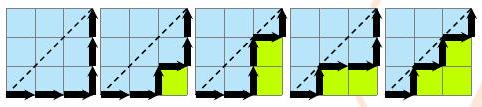

The enumeration of Dyck paths gives the Catalan numbers, sequences which have been around since the 1800’s. By forging a relationship between the affine tableaux and Dyck paths, we are finally able to deduce natural combinatorial rules for computing $k$-Schur functions.

Most exciting is the wealth of new problems springing from this approach; there is enough fodder to feed the hungriest of combinatorial monsters.

## Brian Parshall, Gordon Whyburn Professor of Mathematics Emeritus

Brian’s research is in representation theory and cohomology of algebraic and quantum groups, as well as of finite dimensional Lie and associative algebras. It remains highly influential. He published over 100 articles and mentored 9 Ph.D. students, and helped found in 2009 the NSF-funded annual workshop series called Southeastern Lie Theory.

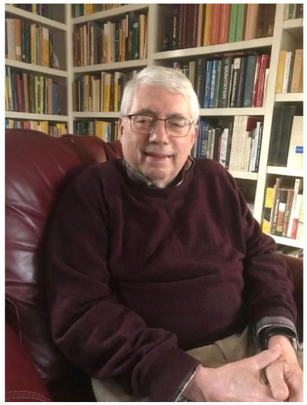

Brian Parshall

Numerous practicing mathematicians today are grateful for his mentorship and intellectual leadership. Especially noteworthy are Brian’s research collaborations. One famous collaboration, known as CPS, for Edward Cline, Brian Parshall, and Leonard Scott, created its first joint research publication at UVA in 1972-3, and twenty-eight in all over the ensuing 40 years, until Ed Cline’s death in 2012. The trio CPS is believed to be the longest running three person research team known in all of mathematics. Brian had other high profile collaborations, including seven publications with Jianpan Wang at East China Normal University, who later became president of that university, and thirteen with Eric Friedlander of Southern California University, who later served a term as President of the (national flagship) American Mathematical Society. Brian, himself, was named a Fellow of the American Mathematical Society in 2012.

Brian retires from active service to the University in 2020 but will continue his scholarship and mentorship for many years to come.

## Bridge to the Doctorate Program

*By David Sherman*

In Fall 2020 the math department was one of five UVa departments to welcome its first cohort in a new graduate school initiative, the Bridge to the Doctorate. This is a post-baccalaureate program for students from groups that are underrepresented in their disciplines and who have not had sufficient training and research experiences to prepare them for admission to doctoral programs. Participants are fully funded for two years.

The inaugural group of bridge students is Adrian Avalos, Alex Jenny, and Reina Kirkendall. We are excited about their talent and potential! Unfortunately the pandemic has constrained opportunities to include them in department life, but they are making the best of it, taking classes, meeting with faculty mentors, and participating in online conferences and other opportunities for professional development.

Asked to provide short comments for this article, all three students expressed appreciation for faculty mentoring. Alex stated, "By being supported and encouraged by mentor professors to learn and grow as a mathematician, the bridge program has given me the opportunity to learn topics I would otherwise struggle with alone." Reina wrote, "I have the opportunity to take classes that weren’t offered at my undergraduate institution and I’m excited to learn which math topics excite me." Adrian "suspect(s) that by the end of the bridge program, I will be equipped with the tools necessary to achieve a PhD."

The bridge program is administered within the math department by a committee of seven faculty: myself and Julie Bergner, Evangelia Gazaki, Ben Hayes, Thomas Koberda, Tom Mark, and Tai Melcher. We welcome applicants for Fall 2021, so please pass the word on to any students or communities you think may be interested! The deadline for applications is March 1, and more information can be found at https://math.virginia.edu/graduate/ bridge/, including a link to the application page in the graduate school. Inquiries may be directed to David Sherman (dsherman@virginia.edu).

## Virginia Mathematics Lecture Series

*The Virginia Mathematics Lectures are a Distinguished Lecture Series that IMS established in 2014*

### Spotlight: Ingrid Daubechies

The Department of Mathematics welcomed Ingrid Daubechies for a virtual visit on September 14 and 15, 2020. Her visit featured both a department colloquium and a public lecture, as well as a lunch with our local AWM chapter.

Ingrid Daubechies is the James Duke Professor of Mathematics and Computer Engineering at Duke University. She is recognized for her study of the mathematical methods that enhance image-compression technology. Professor Daubechies is a member of the National Academy of Engineering, the National Academy of Sciences (NAS), and the American Academy of Arts and Sciences. Her research accomplishments have garnered her a MacArthur Fellowship, NAS Mathematics Prize, Steele Prize, and Nemmers Prize, to name a few.

Professor Daubechies’ colloquium discussed diffusion methods

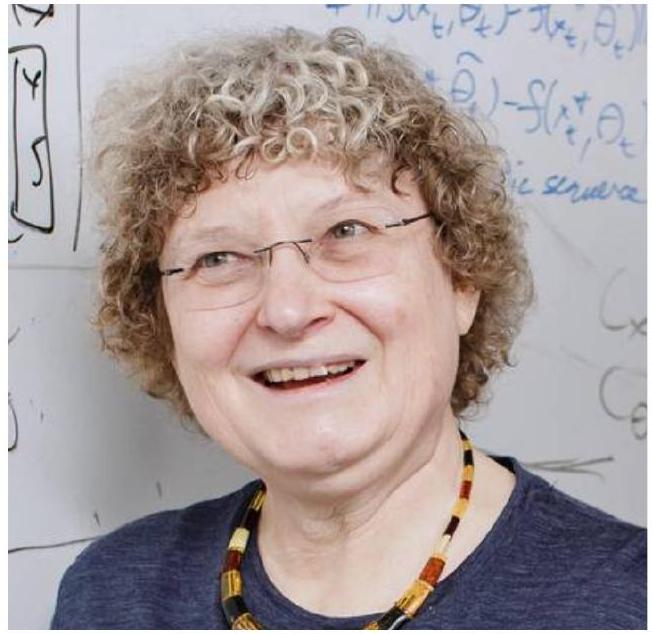

that can be used to identify low-dimensional manifolds underlying high-dimensional datasets, and illustrated that by pinpointing additional mathematical structure, improved results can be obtained. Much of the talk drew on a case study from her collaboration with biological morphologists.

Her public lecture highlighted ways that mathematics can help art historians and art conservators to study and understand art works, their manufacture process, and their state of conservation. Her talk featured several instances of such collaborations, explaining the role of mathematics and illustrating the approach with extensive documentation of the art.

Professor Daubechies also participated in one of the UVa AWM chapter’s lunchtime Q&A’s, which was a great opportunity for members of our community to hear more informally about her mathematics and her distinguished career.

### Spotlight: Greg Lawler

The 12th Virginia Mathematics Lectures were given at UVa by Greg Lawler February 12-14, 2020.

Greg Lawler is the George Wells Beadle Distinguished Service Professor of Mathematics and Statistics at the University of Chicago. Professor Lawler has made many contributions to probability theory and is particularly known for his work in developing the theory of the Schramm-Loewner evolution. He is a fellow of the American Mathematical Society, and a recipient of the George Pólya Prize and the Wolf Prize in Mathematics.

His first lecture "Random walks: Simple and self-avoiding" began with a review of the most common model for random behavior,

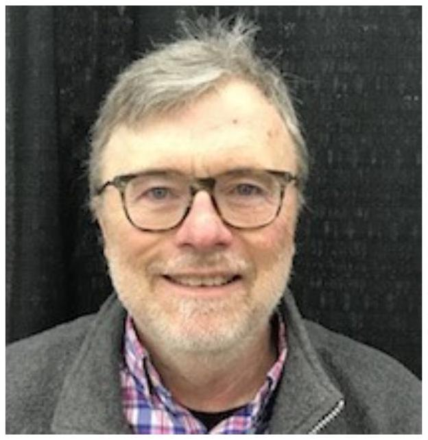

the "drunkard’s walk", where at each time an individual chooses their step from some probability distribution. He discussed what happens when one puts some constraints on the walker to try to avoid places already visited, and he explored the relationship between the "fractal dimension" of a random path and the ambient dimension in which it lives.

The second lecture "Conformal invariance and the two-dimensional critical phenomenon" focused on the prediction by theoretical physicists that lattice models from equilibrium statistical physics "at criticality" in two dimensions have limits that are conformally invariant. Professor Lawler surveyed some of the incredible work of the last twenty years making these ideas precise and rigorous, the starting point of which was the development of the Schramm-Loewner evolution.

The final lecture "Loop measures and the loop-erased random walk" described some relatively recent work on two related models, loop measures and the loop-erased random walk.

## Undergraduate Accomplishments

### Distinguished Major Program

In its third year, our revamped Distinguished Major Program continues to pick up pace. This year four students — Sebastian Haney, Yifei Yang, Trent Lucas, and Brandon Ward — successfully completed the distinguished mathematics major program. This involves completing a research project under the supervision of the faculty member, assembling their findings in a thesis and presenting these at a public defense.

#### Sebastian Haney (Advisor: Tom Mark)

Title: Cylindrical contact homology of Brieskorn $3$-manifolds Abstract: Cylindrical contact homology (CCH) is a Floer-theoretic invariant of contact manifolds proposed in 2000 by Eliashberg, Givental, and Hofer as part of the symplectic field theory package. Intuitively cylindrical contact homology is an attempt to define the Morse homology of a certain action functional induced by a contact form. Defining CCH in full generality is still a work in progress, but in 2019 Hutchings and Nelson showed that it is a well-defined contact invariant for a subclass of contact $3$-manifolds satisfying additional geometric constraints. I will describe joint work with Tom Mark in which we calculate cylindrical contact homology for the Brieskorn $3$-manifolds which are Seifert fibrations over hyperbolic orbifolds with their standard contact structures, which I will also review.

#### Trent Lucas (Advisor: Sara Maloni)

Title: Hyperbolic Structures on Surfaces and their representation space Abstract: Given a surface, viewed as a topological object, we can endow it with a geometry. In fact, we can equip most surfaces with a hyperbolic structure, which is a geometry that locally resembles the hyperbolic plane. Our goal in this talk is to understand the relationship between different hyperbolic structures on the same surface. This is encoded by a space called Teichmüller space, where "points" are hyperbolic structures and similar structures are "close". We will see how the Teichmüller space behaves under a natural action of the symmetry group of a surface (i.e. its mapping class group), and how this generalizes to the representation space of the surface’s fundamental group. In particular, we will discuss a theorem of Marché and Wolff relating a Conjecture of Goldman to a question asked by Bowditch.

#### Brandon Ward (Advisor: Julie Bergner)

Title: Topology, Combinatorics, and Categories: from $\Delta$ to $\Theta_{2}$ Abstract: Finite ordinals arise as we try to model topological spaces by combinatorial information, that is, sets of discrete points and subsets thereof. The collection of all finite ordinals and the order preserving maps between them constitute the category $\Delta$, which we use to define a successful combinatorial model for topological spaces, called simplicial sets. Any map in $\Delta$ can be written as the composite of certain generating maps of $\Delta$; we can explicitly describe simplicial sets by means of these generating maps and the relations amongst them. Our goal in this talk is twofold: first, we consider how $\Delta$ arises in our attempt to model a topological space combinatorially; second, we consider a generalization of $\Delta$, the category $\Theta_{2}$, and try to understand the combinatorics of this category by presenting a set of generating maps and relations amongst them.

#### Yifei Yang (Advisor: Malek Abdesselam)

Title: Diagrammatic Methods in Classical Invariant Theory Abstract: Classical invariant theory studies the properties of polynomials. In particular, we wish to learn when polynomial functions will stay "invariant" or "unchanged" under the actions of linear groups. We will provide a basic overview of invariants and covariants under the context of binary forms and the special linear group $\mathrm{SL}_{2}$. Furthermore, we would like to introduce an alternative approach to investigate invariant theory: the diagrammatic methods. Developed from 19th century invariant theories, diagrammatic methods construct graphical representations to describe algebraic objects such as matrices, tensors, binary forms, and covariants. We hope to offer an expository view about how the diagrammatic methods work and serve as an intrinsic way to analyze invariant theory.

### 2019-2020 Mathematics Department Prize Winners

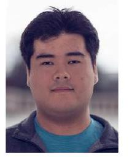

Sebastian Haney

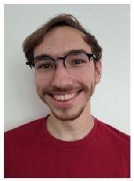

Trent Lucas

#### E.J. McShane Prize: Sebastian Haney and Trent Lucas

The E.J. McShane Prize is given annually to graduating math majors of outstanding achievement in mathematics.

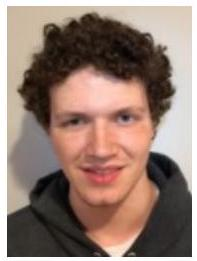

Zachary Baugher

#### Edwin E. Floyd Prize: Nathan Li and Zach Baugher

The Edwin E. Floyd Prize is given annually to second- or third-year majors who show exceptional promise in mathematics.

## Undergraduate Activities

### Undergraduate Research: Mathematical Fluid Dynamics

*By Zoran Grujić*

Mathematical fluid dynamics is an area of applied analysis tasked with providing a mathematical framework for the scientific study of fluid flows, and in particular with infusing mathematical rigor into turbulence phenomenology. One of the key principles of turbulence is the energy cascade: the energy is transferred from larger to smaller scales (a nonlinear process), and the cascade continues until a ‘dissipation scale’ is reached—at this point, the diffusion (a linear process) takes over and dissipates the energy in the form of heat. One of the big challenges has been relating the geometry of the flow with the analytical theory.

In Summer 2018, math major Jiayi Wang explored a possibility of a power-law dependence between a ‘typical small scale’ associated with the coherent vortex structures in a 3D turbulent channel, a geometric scale, and an analytic dissipation scale. One should note that the rigorous theory here is fundamentally incomplete. In this project, Jiayi made use of a dataset made publicly available as a part of the Johns Hopkins Turbulence Database (JHTDB). Once the data was harvested, she visualized the coherent vortex structures in

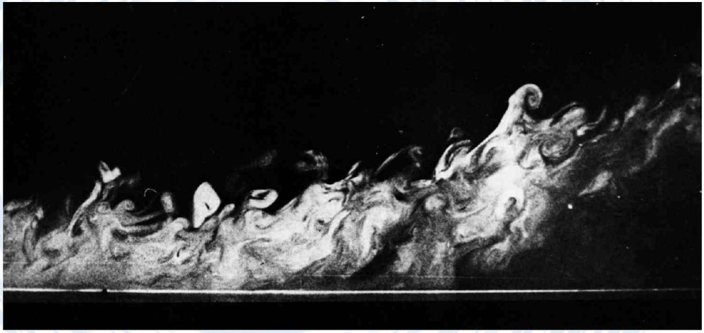

coherent vortex structures in turbulent boundary layer, from An Album of Fluid Motion by Milton Van Dyke

ParaView, extracted the information on the ‘scale of sparseness’ of the regions of intense vorticity, and performed the data analysis. The investigation revealed that there is indeed a statistically significant evidence of the power-law dependence, providing a boost for the future theoretical efforts.

In summer 2019, Jiayi engaged in her second REU-type research project under the guidance of mathematics professor Zoran Grujic. This time, the topic was the study of possible formation of singularities in the 3D fractional Navier-Stokes (NS) equations, describing the motion of a 3D incompressible, viscous, Newtonian fluid with a reduced diffusion described by the fractional Laplacian operator. The fractional NS equations serve as a bridge between the 3D Navier-Stokes equations (full diffusion, described by the classical Laplace operator) and the 3D Euler equations (inviscid flow, zero diffusion). The question of whether a singularity can form in an initially smooth/regular flow is still open for the full range of the models, from Euler to NS, and is one of the major open problems in the mathematical physics. A physically relevant task is to formulate a condition—consistent with the geometry of turbulent flows observed in the highly-resolved computational simulations—that would prevent a singularity formation. There is a nontrivial amount of work in this direction in the case of both Euler and NS equations, but very little in the case of the fractional NS. One of the prominent morphological signatures of turbulent flows is the local coherence of the vorticity direction, i.e., locally, the vortex lines are nearly-aligned. This is especially visible in the regions of intense vorticity. In her work, Jiayi established that a scaling-invariant, dynamical balance between the coherence of the vorticity direction and the vorticity magnitude, in the averaged sense, suffices to prevent a formation of the singularity—the first result of this type for the fractional NS. The proof utilized an array of sophisticated tools from functional and harmonic analysis, and is on the level of a Ph.D. student actively working in this area.

As a matter of fact, this work resulted in her solo paper, Balance of the vorticity direction and the vorticity magnitude in 3D fractional Navier-Stokes equations, Applied Mathematics & Optimization (a highly ranked journal in applied analysis), https://doi.org/10.1007/s00245-020-09684-1. In addition, Jiayi presented her findings at MAA Undergraduate Poster Session at the Joint Mathematics Meeting (JMM) in Denver, Colorado, where she received an "Outstanding Poster" award. She is currently applying for graduate programs in mathematics and applied mathematics.

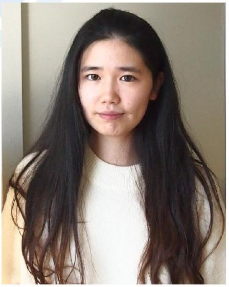

Jiayi Wang

UVa Mathematics is running a similar program in 2021 (see https://uva.theopenscholar.com/reu/program). The deadline for 2021 applications for the 2021 program is February 15, 2021. Please spread the word.